# single-cell RNA-seq workshop: Session 3

Reuben Thomas

10/25/2021

## Background

We went over a series of steps involved in processing scRNA-seq data in general. The aims of these steps included loading, filtering, normalizing for differences between cells, visualizing and clustering the data. He used the data from this study that aimed to understand the effects of stromal cells in developing tumors.

To further illustrate and develop the ideas, methods and steps, I will use a subset of cells from this melanoma data - cells marked by CD45- GFP+ CD31- or inferred as cancer-associated fibroblasts at the 5 day and 11 day time-points. The main reason for choosing this subset is so that we have data of a managable size to perform the planned analyses in this section in the alloted time. You should be able to extend the methods/code to data with larger number of cells and/or variables.

**Biological question:**

1. Identify the main cell-types (or clusters) in the data using marker genes
2. Identify a set of genes whose mean (across sampled animals, **note:** I don’t say sampled cells) expression changes from the 5 day to the 11 day time-point in tumor cancer-associated fibroblast cells given the **experiment design**.
3. Identify the clusters (cell-types) for which the proportion of cells from each animal belonging to it is associated with the time-point
4. Assuming, the data was generated in two different batches, corrected for these effects

**Experimental Design:** At each time-point (5 day or 11 day) cancer associated fibroblast cells are randomly sampled from two mice that are in turn randomly sampled from a pool of C57BL/6 mice. The expression of all genes within each of the cells are assayed using the SMART-Seq2 protocol.

We are interested in the effect of time on gene expression in cancer-associated fibroblasts. However, the expression of gene in a cell is variable not just because of biological reasons like cell-to-cell (intra-animal) and animal-to-animal (inter-animal) variability but also due to technical reasons like the differences in sequencing depth from cell-to-cell, library preparation, animal handling etc. If we don’t fully account for these sources of variation then our results/interpretation may be incorrect. For example, the clustering of cells may be driven by some techninal factors.

Ideally, the claim we would like to make would be as generalizable as possible, i.e., if somebody else were to repeat the experiment above, go back and randomly sample animals, randomly sample cells from each of these animals at two time-points and sequence the RNA in these cells they would make similar claims. So we would like to demonstrate to a sceptical reviewer that despite all the variability in expression we can claim that the fact that we observe mean expression of a gene at day 11 is *x* times higher than its expression at day 5 is unlikely to driven by random chance. Therefore, in arriving at our conclusions we would formally need to account for the different sources of variation. We will do go over these four steps in the following code:

1. Normalization
2. Identification of marker genes
3. Multi-sample multi-condition comparison
4. Batch correction

```r
##remove all data: start from scratch
rm(list = ls())
#Load the libraries
suppressMessages(library(Seurat))
suppressMessages(library(muscat))
suppressMessages(library(SummarizedExperiment))
suppressMessages(library(tidyverse))
suppressMessages(library(magrittr))



raw_data <- read.csv("rawCounts.csv", header = T)
pheno_data <- read.csv("sub_pheno_data.csv", header = T)
print(dim(raw_data))
```

```
## [1] 38293   314
```

```r
print(dim(pheno_data))
```

```
## [1] 313   7
```

```r
##randomly introduce batch information for illustrating batch correction procedure later in the code
##Individuals 1197 and 1235 are assigned to batch 1
##Individuals 1200 and 1242 are assigned to batch 2
batch <- rep("batch1", nrow(pheno_data))
batch[pheno_data$Individual==1200 | pheno_data$Individual==1242] <- "batch2"
pheno_data <- data.frame(pheno_data, batch)

head(pheno_data)
```

```
##             X       FacsMarker Individual             InferredCellType Organ
## 1 22028_3_121 CD45- GFP+ CD31-       1197 cancer associated fibroblast  skin
## 2 22028_3_123 CD45- GFP+ CD31-       1197 cancer associated fibroblast  skin
## 3 22028_3_125 CD45- GFP+ CD31-       1197 cancer associated fibroblast  skin
## 4 22028_3_129 CD45- GFP+ CD31-       1197 cancer associated fibroblast  skin
## 5 22028_3_131 CD45- GFP+ CD31-       1197 cancer associated fibroblast  skin
## 6 22028_3_133 CD45- GFP+ CD31-       1197 cancer associated fibroblast  skin
##   SamplingSite  Time  batch
## 1        tumor 5 day batch1
## 2        tumor 5 day batch1
## 3        tumor 5 day batch1
## 4        tumor 5 day batch1
## 5        tumor 5 day batch1
## 6        tumor 5 day batch1
```

We will map the ensembl ids to gene symbols and load the data as a Seurat object. Seurat provides convenient functions to filter the cells and visualize the data. We will then use the data from the filtered cells for the sctransform normalization and further analyses.

```r
mm10_genes <- read.csv("mm10_genes.tsv", header=FALSE, sep='\t', stringsAsFactors=FALSE,
                       col.names=c("ensembl_id", "gene_symbol"))

gene_ids <- as.character(raw_data$Geneid)

raw_data <- raw_data[,-1]
row.names(raw_data) <- gene_ids

# Map ENSEMBL Ids to their gene symbols
TempIndices <- match(gene_ids, mm10_genes$ensembl_id)
raw_data <- raw_data[!is.na(TempIndices), ]
CheckIds <- row.names(raw_data)[1:5]
NonUniqueGeneSymbols <-  mm10_genes$gene_symbol[TempIndices[!is.na(TempIndices)]]
UniqueGeneSymbols <- paste(NonUniqueGeneSymbols, 1:length(NonUniqueGeneSymbols), sep="_")
row.names(raw_data) <- UniqueGeneSymbols
colnames(raw_data) <- pheno_data$X

row.names(pheno_data) <- as.character(pheno_data$X)
pheno_data <- pheno_data[,-1]

# Finally, wrap this matrix up in a Seurat Object
data <- CreateSeuratObject(counts=raw_data,
                           project="basic_analysis",
                           min.cells=3,
                           min.features=200,
                           names.delim=NULL,
                           meta.data = pheno_data)
# First, find all mitochondrial genes, and count them as a percentage of total reads/cell
# In mouse, mitochondrial genes start with "mt-" so find all genes that match that pattern
# If you were doing this in a human dataset the pattern would be "^MT-"
data[["percent_mt"]] <- PercentageFeatureSet(object=data, pattern="^mt-")


# Typically, you would use much lower thresholds for mitochondrial genes (< 5%)
# This data set has lots of highly expressed mitochondrial genes though, so we'll leave them
quantnCountRNA <- quantile(data@meta.data$nCount_RNA, 0.05)
data <- subset(x=data, subset=nFeature_RNA > 200 & nCount_RNA > quantnCountRNA & percent_mt < 20)

print(sprintf("After filtering outliers: %d cells and %d genes", ncol(data), nrow(data)))
```

```
## [1] "After filtering outliers: 297 cells and 16148 genes"
```

## Normalization

Now, we will perform sctranform based normalization and visualize the results

```r
data <- SCTransform(data, method="qpoisson", vars.to.regress = NULL)
```

```
## Calculating cell attributes from input UMI matrix: log_umi
```

```
## Variance stabilizing transformation of count matrix of size 15163 by 297
```

```
## Model formula is y ~ log_umi
```

```
## Get Negative Binomial regression parameters per gene
```

```
## Using 2000 genes, 297 cells
```

```
## Found 1 outliers - those will be ignored in fitting/regularization step
```

```
## Second step: Get residuals using fitted parameters for 15163 genes
```

```
## Computing corrected count matrix for 15163 genes
```

```
## Wall clock passed: Time difference of 3.042193 secs
```

```
## Determine variable features
```

```
## Place corrected count matrix in counts slot
```

```
## Centering data matrix
```

```
## Set default assay to SCT
```

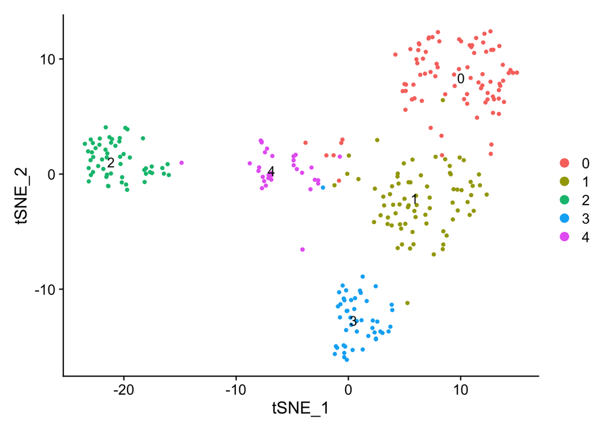

```r
data <- RunPCA(data, verbose = FALSE)
data <- RunTSNE(data, dims = 1:30, verbose = FALSE)

data <- FindNeighbors(data, dims = 1:30, verbose = FALSE)
data <- FindClusters(data, verbose = FALSE)
DimPlot(data, label = TRUE, reduction = "tsne")
```

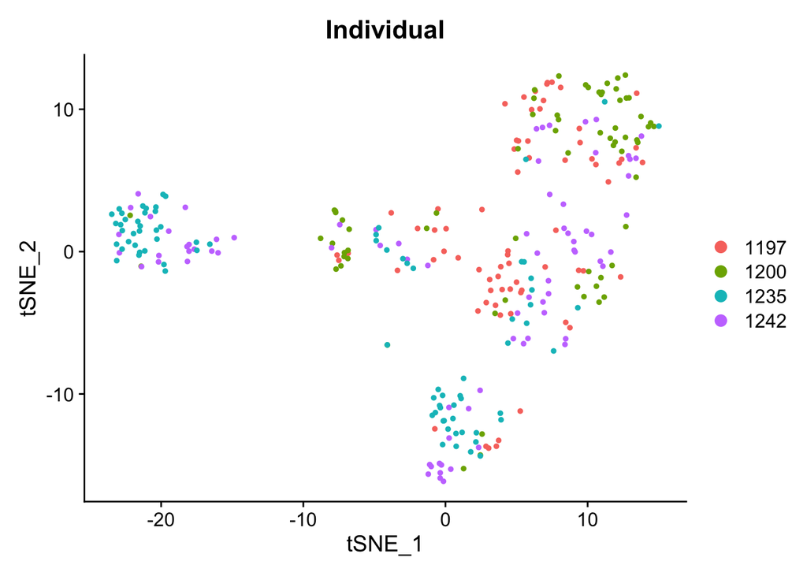

```r
DimPlot(data, reduction = "tsne", group.by = "Individual")
```

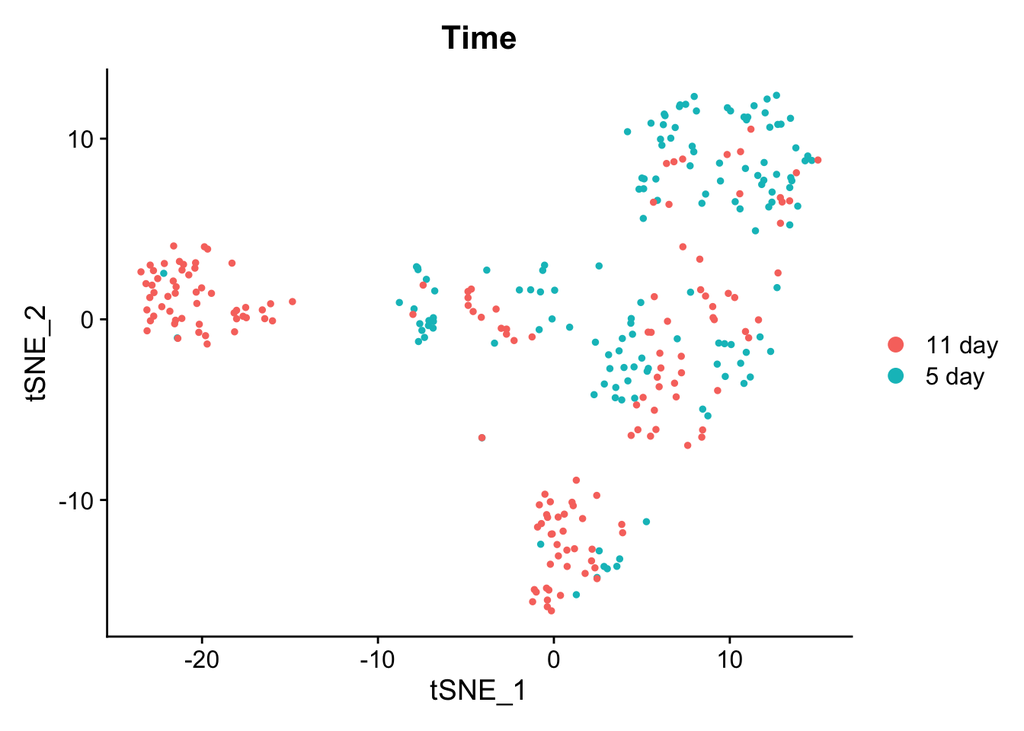

```r
DimPlot(data, reduction = "tsne", group.by = "Time")
```

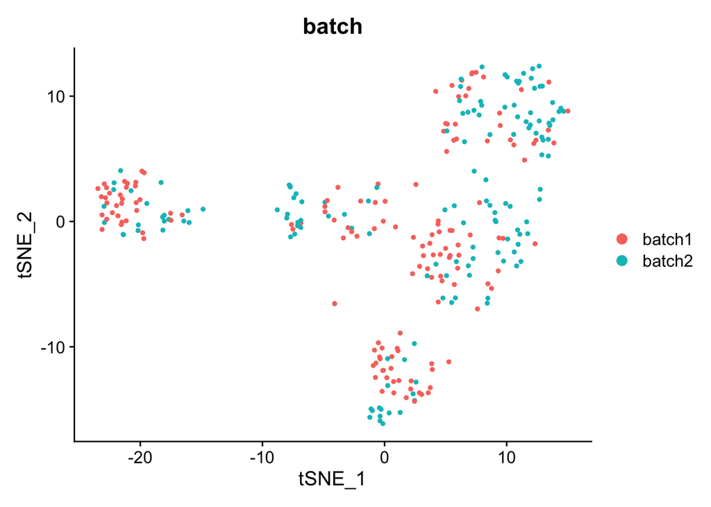

```r
DimPlot(data, reduction = "tsne", group.by = "batch")
```

```r
# ## Note there still appears to be an association of PC1 with nFeature_RNA
# FeatureScatter(object=data, feature1="nFeature_RNA", feature2="PC_1")
```

```r
## Find markers for each of the 5 clusters
# MarkersRes <- FindAllMarkers(data, assay = "SCT", slot = "data", test.use = "wilcox", return.thresh = 1e-6)

## Find markers for cluster 0
MarkersRes1 <- FindMarkers(data, ident.1 = 0, assay = "SCT",slot = "data", test.use = "wilcox", return.thresh = 1e-6)
head(MarkersRes1)
```

```
##                     p_val avg_log2FC pct.1 pct.2    p_val_adj
## Clec3b-23561 3.268952e-49   4.794032 0.966 0.129 4.956711e-45
## C3-9726      9.843640e-40   4.616186 1.000 0.595 1.492591e-35
## Dpt-996      1.370552e-39   4.095372 1.000 0.510 2.078168e-35
## Dpep1-22170  3.770131e-39   4.268794 1.000 0.338 5.716650e-35
## Gsn-11656    8.451417e-39   4.353616 1.000 0.995 1.281488e-34
## Dcn-2135     8.793819e-39   3.374646 1.000 0.648 1.333407e-34
```

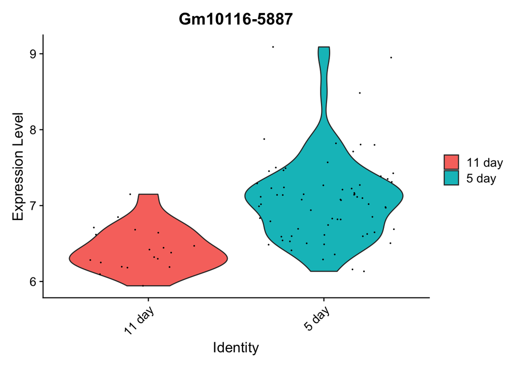

```r
## Find genes associated with time in cluster 0.
## Note: this is not the recommended approach to do this since instead of individual mice being treated as replicates, the cells are being treated as such
cluster0_data <- subset(x=data, subset=(seurat_clusters==0))
MarkersRes0 <- FindMarkers(cluster0_data, ident.1 = "5 day", group.by = "Time", assay = "SCT",slot = "data", test.use = "wilcox", return.thresh = 1e-6)
VlnPlot(cluster0_data, features = "Gm10116-5887", group.by = "Time")
```

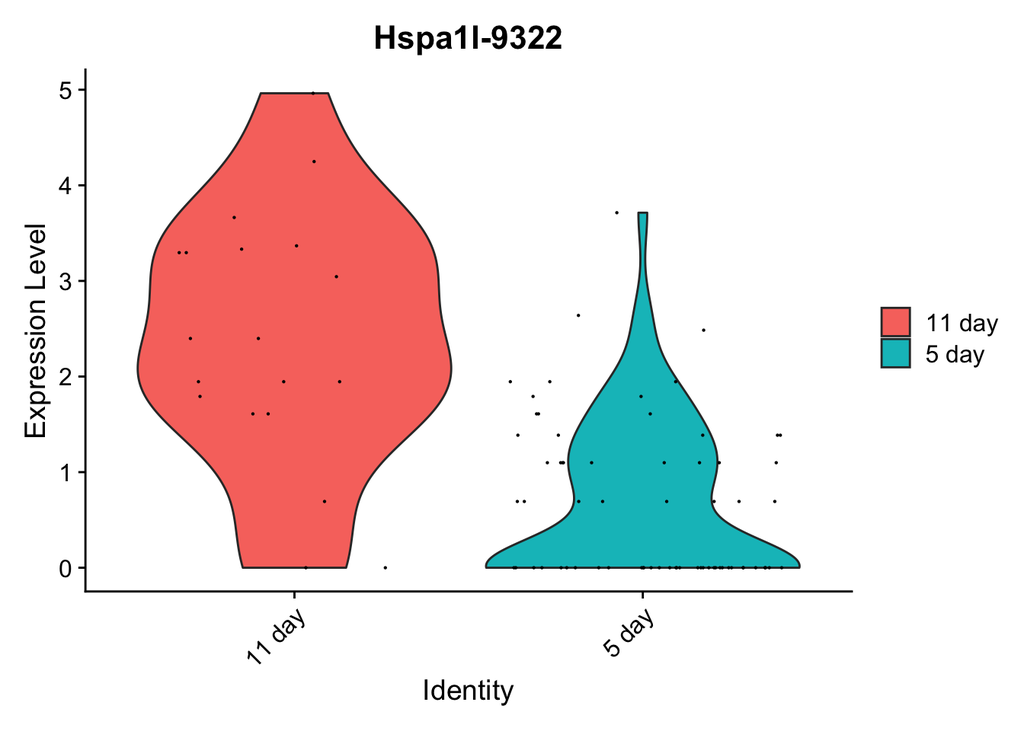

```r
VlnPlot(cluster0_data, features = "Hspa1l-9322", group.by = "Time")
```

## Batch correction

Below, we will go over code to remove potential batch effects in the data using the IntegrateData function in Seurat 3. We will use the same data as before, assuming that the data was generated in two batches. It was not, :). But lets pretend anyway.

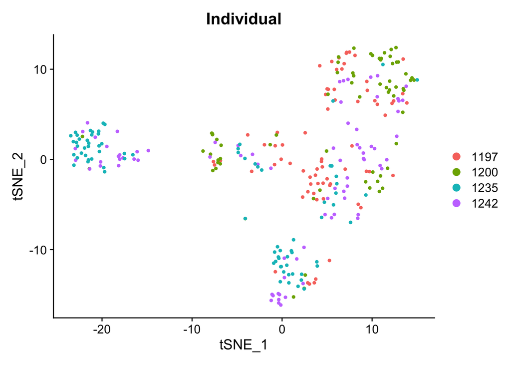

```r
## Let us visualize the uncorrected data
DimPlot(data, reduction = "tsne", group.by = "Individual")
```

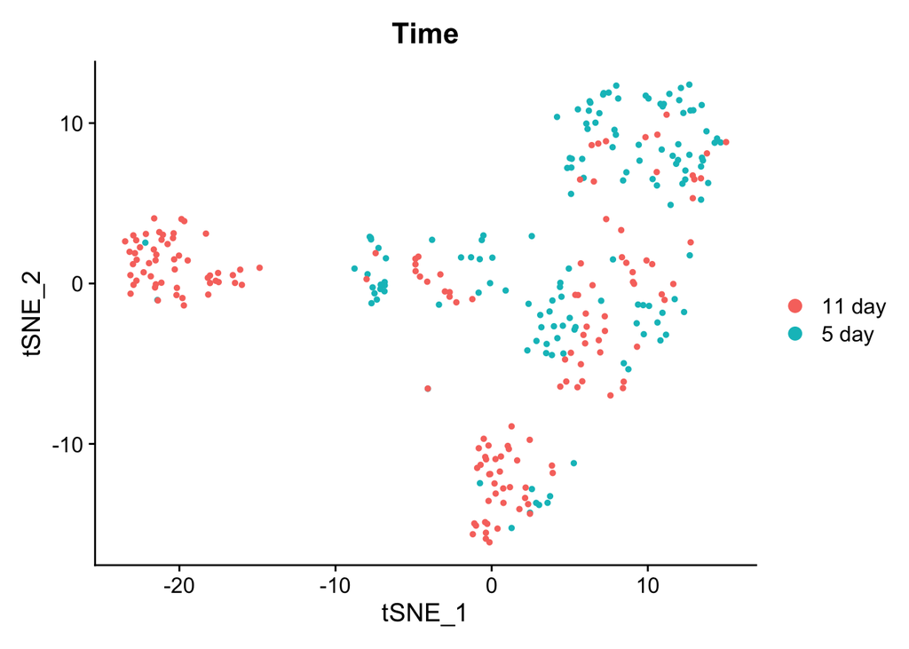

```r
DimPlot(data, reduction = "tsne", group.by = "Time")
```

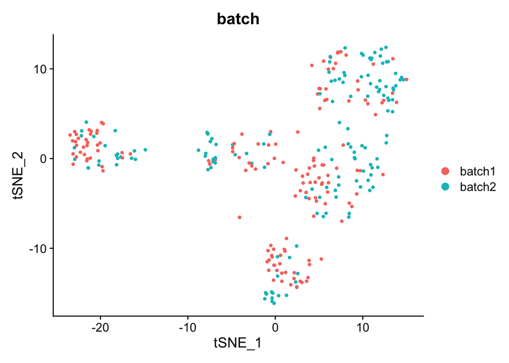

```r
DimPlot(data, reduction = "tsne", group.by = "batch")
```

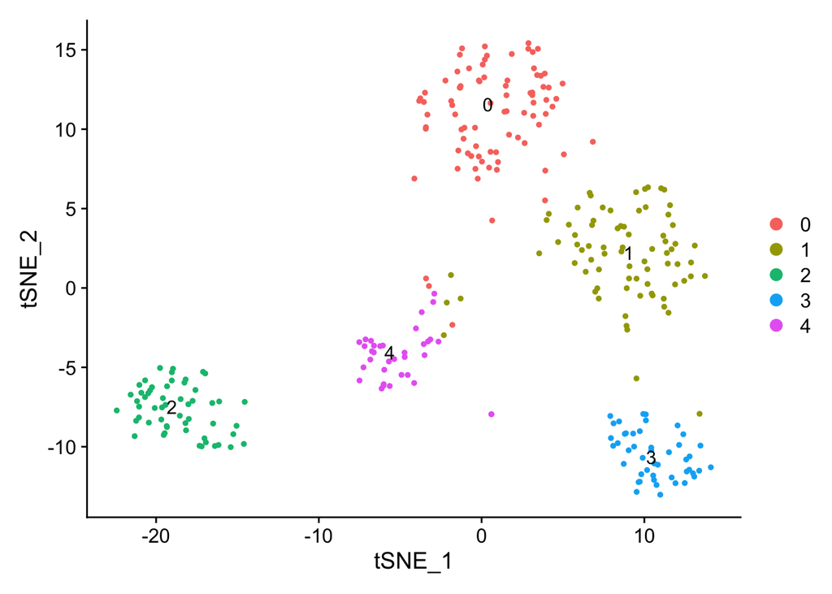

```r
## Split the cells between the two batches
batch.list <- SplitObject(data, split.by = "batch")

## Normalize the read counts across cells within the same bench
for (i in 1:length(batch.list)) {
  batch.list[[i]] <- SCTransform(batch.list[[i]], verbose = FALSE, method="qpoisson", vars.to.regress = NULL)
}

## Select features to identify anchors
batch.features <- SelectIntegrationFeatures(object.list = batch.list, nfeatures = 3000)
batch.list <- PrepSCTIntegration(object.list = batch.list, anchor.features = batch.features,
                                    verbose = FALSE)
## Find the anchors
batch.anchors <- FindIntegrationAnchors(object.list = batch.list, normalization.method = "SCT",
                                           anchor.features = batch.features, verbose = FALSE, k.filter  = 10)
## Integrate the data
batch.integrated <- IntegrateData(anchorset = batch.anchors, normalization.method = "SCT",
                                     verbose = FALSE)

## Let us visualize the "corrected" data
batch.integrated <- RunPCA(batch.integrated, verbose = FALSE)
batch.integrated <- RunTSNE(batch.integrated, dims = 1:30, verbose = FALSE)

batch.integrated <- FindNeighbors(batch.integrated, dims = 1:30, verbose = FALSE)
batch.integrated <- FindClusters(batch.integrated, verbose = FALSE)
DimPlot(batch.integrated, label = TRUE, reduction = "tsne")
```

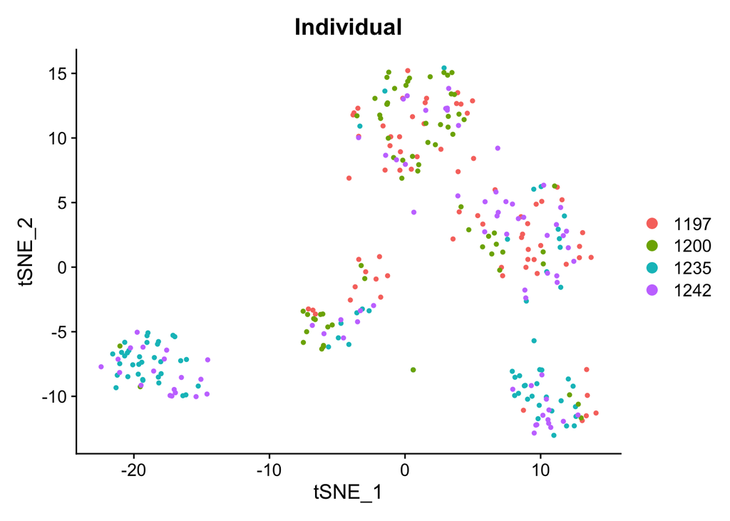

```r
DimPlot(batch.integrated, reduction = "tsne", group.by = "Individual")
```

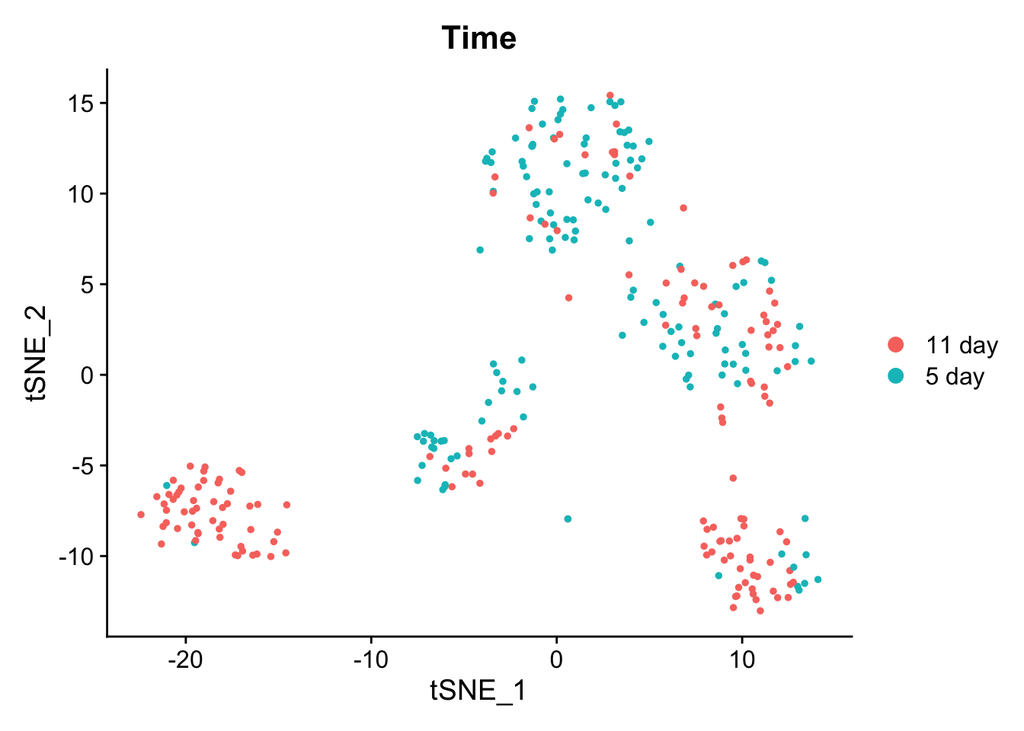

```r
DimPlot(batch.integrated, reduction = "tsne", group.by = "Time")
```

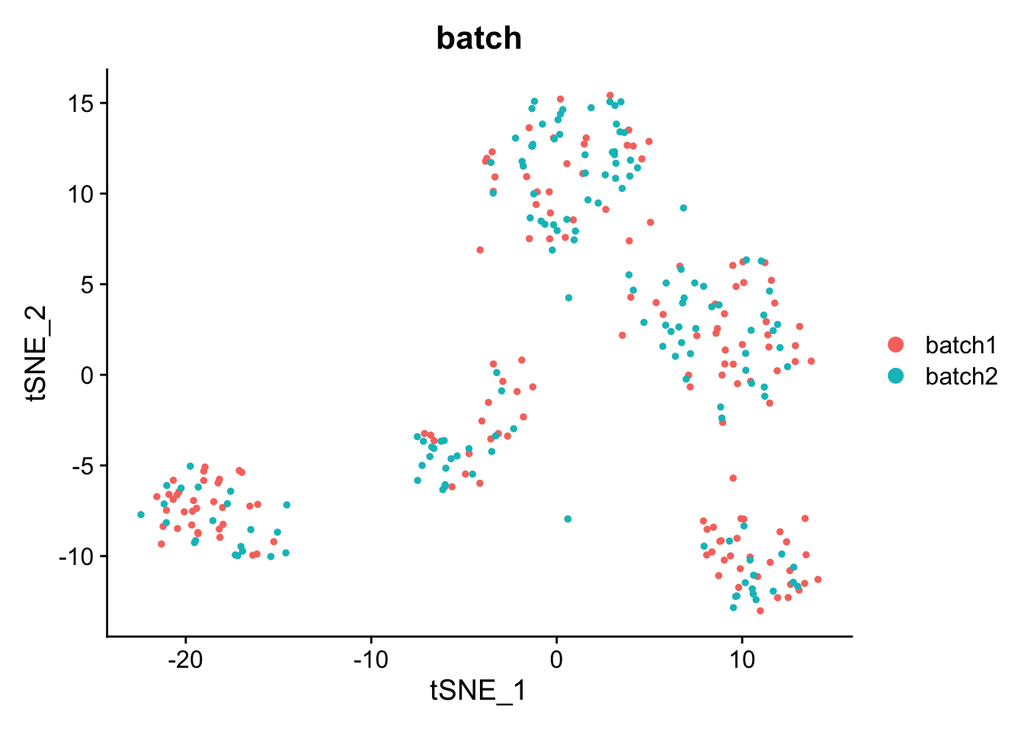

```r
DimPlot(batch.integrated, reduction = "tsne", group.by = "batch")
```

## Multi-sample multi-condition comparison

We will aggregate the counts across cells from each mouse within each cluster so that now we will be able to perform a pseudo-bulk RNA-seq differential expression separtely within each cluster. Note, we will be able to treat individual mice as replicates with this analyses. For the analyses in this section, we are moving away from Seurat. Hence we need to create a new single-cell RNA-seq object that the typical bioconductor package will recognise.

### Within -cluster comparison

The bioconductor package **muscat** will help us with this analysis. I illustrate below how to set up the design matrix to perform the differential expression analyses. I prefer this approach as opposed to typical approach to assuming a two condition comparison. This way you have a lot of flexibility in modeling more complex design with more than one variable along with interactions between variables of interest.

```r
## Add modified names for the Time and Individual variable to make them work "nice" with the subsequent analysis in this code
data[["sTime"]] <- (data@meta.data$Time) %>%
  as.character() %>%
    gsub(" ", "_", .) %>%
    make.names()
data[["sIndividual"]] <- (data@meta.data$Individual) %>%
  as.character() %>%
  paste0("Individual_",.)

head(data@meta.data)
```

```
##             orig.ident nCount_RNA nFeature_RNA       FacsMarker Individual
## 22028_3_121          2     312643         4457 CD45- GFP+ CD31-       1197
## 22028_3_123          2     368024         1639 CD45- GFP+ CD31-       1197
## 22028_3_125          2    1069902         4187 CD45- GFP+ CD31-       1197
## 22028_3_131          2    1401179         6841 CD45- GFP+ CD31-       1197
## 22028_3_133          2    1365745         5857 CD45- GFP+ CD31-       1197
## 22028_3_135          2    1163445         5613 CD45- GFP+ CD31-       1197
##                         InferredCellType Organ SamplingSite  Time  batch
## 22028_3_121 cancer associated fibroblast  skin        tumor 5 day batch1
## 22028_3_123 cancer associated fibroblast  skin        tumor 5 day batch1
## 22028_3_125 cancer associated fibroblast  skin        tumor 5 day batch1
## 22028_3_131 cancer associated fibroblast  skin        tumor 5 day batch1
## 22028_3_133 cancer associated fibroblast  skin        tumor 5 day batch1
## 22028_3_135 cancer associated fibroblast  skin        tumor 5 day batch1
##             percent_mt nCount_SCT nFeature_SCT SCT_snn_res.0.8 seurat_clusters
## 22028_3_121   1.181859     617938         4625               0               0
## 22028_3_123   3.632644     615456         1823               0               0
## 22028_3_125   0.824468     624177         3871               0               0
## 22028_3_131   1.430081     627706         6403               1               1
## 22028_3_133   1.262534     626974         5209               1               1
## 22028_3_135   2.624447     627235         5040               0               0
##              sTime     sIndividual
## 22028_3_121 X5_day Individual_1197
## 22028_3_123 X5_day Individual_1197
## 22028_3_125 X5_day Individual_1197
## 22028_3_131 X5_day Individual_1197
## 22028_3_133 X5_day Individual_1197
## 22028_3_135 X5_day Individual_1197
```

```r
## Store the meta-data for each cell in the PhenoData object
PhenoData <- data@meta.data

## For this analysis we are moving away from Seurat. Hence we need to create a new single-cell RNA-seq object that the typical bioconductor package will recognise.
## Create SingleCellExperiment object
sce <- SummarizedExperiment(assays=list(counts=data@assays$RNA@counts, logcounts=data@assays$RNA@data), colData=PhenoData)
sce <- as(sce, "SingleCellExperiment")

## Prep this object for subsequent aggregation analyses
(sce <- prepSCE(sce,
                kid = "seurat_clusters", # subpopulation assignments
                gid = "sTime",  # group IDs
                sid = "sIndividual",   # sample IDs
                drop = TRUE))  # drop all other colData columns
```

```
## class: SingleCellExperiment
## dim: 16148 297
## metadata(1): experiment_info
## assays(2): counts logcounts
## rownames(16148): Sox17-4 Mrpl15-5 ... Erdr1-24861 Gm21748-24862
## rowData names(0):
## colnames(297): 22028_3_121 22028_3_123 ... 22028_6_97 22028_6_99
## colData names(3): cluster_id sample_id group_id
## reducedDimNames(0):
## mainExpName: NULL
## altExpNames(0):
```

[output not shown]

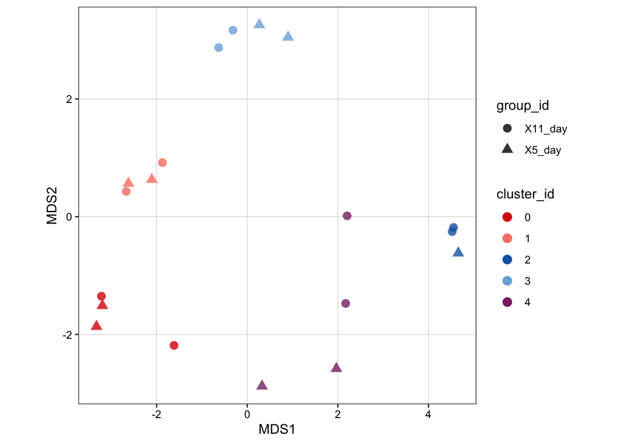

```r
nk <- length(kids <- levels(sce$cluster_id))
ns <- length(sids <- levels(sce$sample_id))
names(kids) <- kids; names(sids) <- sids

##keep those clusters with a median of at least 5 cells across all individual replicates
##In a real data set you can change 5 to something more realistic (100?)
toKeep <- table(sce$cluster_id, sce$sample_id) %>%
  t() %>%
  apply(., 2, function(x) median(x)) %>%
  subset(., is_greater_than(., 5)) %>%
  names()
sce <- subset(sce, , cluster_id %in% toKeep)

## Aggregate counts across cells for each mouse (sample_id) within each cluster (cluster_id)
pb <- aggregateData(sce,
                    assay = "counts", fun = "sum",
                    by = c("cluster_id", "sample_id"))

## Visualize the results in a Multi-Dimensional Scaling (MDS) plot
(pb_mds <- pbMDS(pb))
```

```r
## Set up the design matrix.
group_id <- colData(pb)[,1]
mm <- model.matrix(~ group_id)
colnames(mm) <- levels(pb$group_id)
row.names(mm) <- row.names(colData(pb))
# run DS analysis; This is only two group/sample comparison, so we are interested in testing the significance of the seco nd coefficient (that represent the log FC of gene expression between 5 day time-point and the 11 day time-point)

res <- pbDS(pb, design=mm, coef=2,method="edgeR", verbose=TRUE, min_cells = 3)
##The results are going to be placed in topClusterResults object
tbl <- res$table$X5_day
ClusterNo <- 0
p_thresh <- 0.05
topClusterResults <- NULL
for(i in 1:length(tbl)) {
  temp_ClusterResult <- tbl[[i]]
  # temp_topClusterResult <- temp_ClusterResult[temp_ClusterResult$p_adj.loc < p_thresh, ]
  # temp_topClusterResult <- temp_topClusterResult[order(temp_topClusterResult$p_adj.loc),]
  temp_ClusterResult %<>% filter(p_val < p_thresh)
  temp_ClusterResult %<>% dplyr::slice(order(p_val))
  temp_ClusterResult %<>% rownames_to_column(., var = "Gene")
  topClusterResults %<>% rbind(., temp_ClusterResult)
}
head(topClusterResults)
```

```
##   Gene          gene cluster_id     logFC    logCPM         F        p_val
## 1    1    Tac1-17705          0 13.329720  5.481096 106.31132 0.0003169062
## 2    2  Gm20481-9321          0 -3.290732  9.280148  54.13199 0.0005373008
## 3    3    Apln-23978          0 -4.618837  5.441927  43.66154 0.0009096770
## 4    4   Hspa1b-9319          0 -2.922658 11.268460  32.97678 0.0017801527
## 5    5 Fam198a-23542          0  8.208749  4.528972  32.15742 0.0018886600
## 6    6    Chl1-18454          0 -3.163536  7.252967  31.58391 0.0019700832
##   p_adj.loc p_adj.glb   coef
## 1 0.9995918 0.8218103 X5_day
## 2 0.9995918 0.8218103 X5_day
## 3 0.9995918 0.8218103 X5_day
## 4 0.9995918 0.8218103 X5_day
## 5 0.9995918 0.8218103 X5_day
## 6 0.9995918 0.8218103 X5_day
```

### Between -cluster comparison

For this analyses, we will use the **lme4** package in R to fit generalized linear mixed effects models. We are going the model the change in the chance (or more formally the odds) of cells from a given mouse belonging to a given cluster from the 5 day to the 11 day time-point. The random effects part of these models captures the inherent correlation between the cells coming from the same mouse

```r
##the number of cells in each mouse in each cluster
Ncells <- do.call("rbind",(pb@int_colData$n_cells))
print(Ncells)
```

```
##                  0  1  2  3  4
## Individual_1197 30 31  0  5  5
## Individual_1200 38 11  2  3 14
## Individual_1235  3 10 34 26  7
## Individual_1242 16 23 18 14  7
```

```r
TotalCells <- rowSums(Ncells, na.rm = T)
names(TotalCells) <- row.names(Ncells)

Ncells %<>% as.data.frame() %>% rownames_to_column(., var = "sample_id")
Ncells %<>% gather(.,"cluster_id", "Freq", -"sample_id")
##determine the total number of cells per mouse
Ncells <- Ncells %>%
  filter(Freq > 0)

##load the cluster info and the meta-data per mouse
Clusters <- unique(Ncells$cluster_id)
SampleInfo <- colData(pb)

##function to estimate the change in the odds of cluster membership from the 5 day to the 11 day time-point
estimateCellStateChange <- function(k, Ncells, TotalCells, SampleInfo) {
  require(lme4)
  require(gdata)
  print(paste("Cluster", k))
  Ncells_sub <- Ncells %>%
    filter(cluster_id==k)
  FitData <- NULL
  TempIndices <- match(Ncells_sub$sample_id, names(TotalCells))
  TotalCells_sub <- TotalCells[TempIndices]
  for(i in 1:length(TotalCells_sub)) {
    InCluster=c(rep(1, Ncells_sub$Freq[i]), rep(0, (TotalCells_sub[i]-Ncells_sub$Freq[i])))
    Time=rep(SampleInfo$group_id, TotalCells_sub[i])
    ID=rep(row.names(SampleInfo)[i], TotalCells_sub[i])
    TempData <- data.frame(ID, InCluster, Time)
    FitData <- rbind(FitData, TempData)
  }
  FitData$Time <- relevel(FitData$Time, ref="X5_day")
  FitData$InCluster <- as.factor(FitData$InCluster)
  glmerFit1 <- glmer(InCluster ~ (1|ID) + Time, data=FitData, family = "binomial")
  sglmerFit1 <- summary(glmerFit1)
  TempRes1 <- (sglmerFit1$coefficients[-1,])


  return(TempRes1)
}

ClusterRes <- sapply(Clusters, estimateCellStateChange, Ncells, TotalCells, SampleInfo)
```

```
## gdata: read.xls support for 'XLS' (Excel 97-2004) files ENABLED.
```

```
## gdata: read.xls support for 'XLSX' (Excel 2007+) files ENABLED.
```

```
## [1] "Cluster 0"
## [1] "Cluster 1"
## [1] "Cluster 2"
## [1] "Cluster 3"
## [1] "Cluster 4"
```

```r
ClusterRes %<>%
  as.data.frame() %>%
  t()
row.names(ClusterRes) <-  paste0("Cluster", Clusters)
ClusterRes <- data.frame(ClusterRes)
colnames(ClusterRes)[c(1,4)] <- c("logOddsRatio_11day_vs_5day","pvalue")

##perform multiple-testing correction
ClusterRes <- data.frame(ClusterRes, p.adjust= p.adjust(ClusterRes$pvalue, method = "BH"))

##output the results
print(ClusterRes)
```

```
##          logOddsRatio_11day_vs_5day Std..Error    z.value    pvalue  p.adjust
## Cluster0                 -0.1205012  0.1415755 -0.8511441 0.3946893 0.4041632
## Cluster1                 -0.1157930  0.1388057 -0.8342090 0.4041632 0.4041632
## Cluster2                 -0.2263598  0.1681710 -1.3460100 0.1782993 0.4041632
## Cluster3                 -0.1638158  0.1649122 -0.9933519 0.3205385 0.4041632
## Cluster4                 -0.2099656  0.1868392 -1.1237771 0.2611076 0.4041632
```